# Trabajo grupal. Soluciones

Autor/a

Grupo

# Problema 1

## Enunciado

Un decisor debe elegir entre cuatro alternativas, $d_1$, $d_2$, $d_3$ y $d_4$, ante tres posibles estados de la naturaleza, $e_1$, $e_2$ y $e_3$, cuyas probabilidades de ocurrencia son desconocidas.

La tabla de resultados es la siguiente:

| Alternativa | $e_1$ | $e_2$ | $e_3$ |
| --- | --- | --- | --- |
| $d_1$ | 5 | 9 | 12 |
| $d_2$ | 16 | 22 | 15 |
| $d_3$ | 1 | 14 | 17 |
| $d_4$ | 8 | 21 | 29 |

Se estudiarán dos situaciones:

- **Situación favorable:** los valores de la tabla representan beneficios, por lo que el objetivo será maximizar los resultados.
- **Situación desfavorable:** los valores representan costes, por lo que el objetivo, en este caso, será minimizar los resultados.

Utilizando los criterios clásicos de decisión bajo incertidumbre (Wald, Optimista, Hurwicz, Savage, Laplace y Punto Ideal), y tomando un coeficiente de optimismo $\alpha=0.5$ para el criterio de Hurwicz, se pide determinar cuáles de las siguientes afirmaciones son verdaderas.

1. En situación favorable, el criterio de Wald selecciona la alternativa $d_2$.
2. En situación favorable, el criterio Optimista selecciona la alternativa $d_3$.
3. Para un coeficiente de optimismo $\alpha=0.5$, el criterio de Hurwicz selecciona la posición de mediapunta ($d_3$).
4. El criterio de Savage selecciona la misma alternativa óptima en ambas situaciones.
5. En situación desfavorable, los criterios de Laplace y Punto Ideal seleccionan la misma alternativa óptima.

## Solución

En primer lugar, introducimos la tabla de decisión en R utilizando la función `crea.tablaX()` del archivo `teoriadecision_funciones_incertidumbre.R` .

```r
source("teoriadecision_funciones_incertidumbre.R")

X <- crea.tablaX(
  c(5, 9, 12,
    16, 22, 15,
    1, 14, 17,
    8, 21, 29),
  numalternativas = 4,
  numestados = 3
)

knitr::kable(X, caption = "Tabla de decisión")
```

Tabla de decisión

|  | e1 | e2 | e3 |
| --- | --- | --- | --- |
| d1 | 5 | 9 | 12 |
| d2 | 16 | 22 | 15 |
| d3 | 1 | 14 | 17 |
| d4 | 8 | 21 | 29 |

### Criterio de Wald

El criterio de Wald (también llamado pesimista) selecciona la **alternativa con el mejor resultado dentro del peor escenario posible**.

**Situación favorable**

En este caso, se elige la alternativa que presenta el *mayor de los valores mínimos*:

$$W = \max_i \left\{\min_j x_{ij}\right\}$$

**Situación desfavorable**

En este caso, se elige la alternativa que presenta el *menor de los valores máximos*:

$$W = \min_i \left\{\max_j x_{ij}\right\}$$

Calculamos ambos casos mediante la función `criterio.Wald()` del archivo `teoriadecision_funciones_incertidumbre.R` .:

```r
wald_fav <- criterio.Wald(X, favorable = TRUE)
wald_desfav <- criterio.Wald(X, favorable = FALSE)

tabla_wald <- data.frame(
  Alternativa = rownames(X),
  Favorable = as.numeric(wald_fav$ValorAlternativas),
  Desfavorable = as.numeric(wald_desfav$ValorAlternativas)
)

knitr::kable(
  tabla_wald,
  col.names = c("Alternativa", "Mínimo (beneficios)", "Máximo (costes)"),
  caption = "Valoración de las alternativas según el criterio de Wald"
)
```

Valoración de las alternativas según el criterio de Wald

| Alternativa | Mínimo (beneficios) | Máximo (costes) |
| --- | --- | --- |
| d1 | 5 | 12 |
| d2 | 15 | 22 |
| d3 | 1 | 17 |
| d4 | 8 | 29 |

En situación favorable, la alternativa óptima es $d_2$, debido a que presenta el mayor mínimo, con un valor de 15.

En situación desfavorable, la alternativa óptima es $d_1$, porque presenta el menor máximo, con un valor de 12.

### Criterio Optimista

El criterio Optimista selecciona la **alternativa que presenta el mejor resultado posible**.

**Situación favorable**

Se elige la alternativa que presenta el *mayor de los valores máximos*:

$$O = \max_i \left\{\max_j x_{ij}\right\}$$

**Situación desfavorable**

Se elige la alternativa que presenta el *menor de los valores mínimos*:

$$O = \min_i \left\{\min_j x_{ij}\right\}$$

Calculamos ambos casos mediante la función `criterio.Optimista()`del archivo `teoriadecision_funciones_incertidumbre.R` .:

```r
optimista_fav <- criterio.Optimista(X, favorable = TRUE)
optimista_desfav <- criterio.Optimista(X, favorable = FALSE)

tabla_optimista <- data.frame(
  Alternativa = rownames(X),
  Favorable = as.numeric(optimista_fav$ValorAlternativas),
  Desfavorable = as.numeric(optimista_desfav$ValorAlternativas)
)

knitr::kable(
  tabla_optimista,
  col.names = c("Alternativa", "Máximo (beneficios)", "Mínimo (costes)"),
  caption = "Valoración de las alternativas según el criterio Optimista"
)
```

Valoración de las alternativas según el criterio Optimista

| Alternativa | Máximo (beneficios) | Mínimo (costes) |
| --- | --- | --- |
| d1 | 12 | 5 |
| d2 | 22 | 15 |
| d3 | 17 | 1 |
| d4 | 29 | 8 |

En situación favorable la alternativa óptima es $d_4$, porque presenta el mayor máximo, con un valor de 29.

En situación desfavorable, la alternativa óptima es $d_3$, ya que presenta el menor mínimo, con un valor de 1.

### Criterio de Hurwicz

El criterio de Hurwicz **combina el mejor y el peor resultado de cada alternativa** mediante un coeficiente de optimismo $\alpha \in [0,1]$.

En este problema se considera $\alpha=0.5$, por lo que ambos resultados tienen el mismo peso.

**Situación favorable**

Se calcula la valoración de cada alternativa mediante:

$$H_i=\alpha\max_j x_{ij}+(1-\alpha)\min_j x_{ij}$$

Se selecciona la alternativa con mayor valoración.

**Situación desfavorable**

La valoración de cada alternativa se obtiene mediante:

$$H_i=(1-\alpha)\max_j x_{ij}+\alpha\min_j x_{ij}$$

Se selecciona la *alternativa con menor valoración*.

Procedemos a calcular ambos casos utilizando la función `criterio.Hurwicz()` presente en el archivo anteriormente citado:

```r
hurwicz_fav <- criterio.Hurwicz(
  X, alfa = 0.5, favorable = TRUE
)

hurwicz_desfav <- criterio.Hurwicz(
  X, alfa = 0.5, favorable = FALSE
)

tabla_hurwicz <- data.frame(
  Alternativa = rownames(X),
  Favorable = as.numeric(hurwicz_fav$ValorAlternativas),
  Desfavorable = as.numeric(hurwicz_desfav$ValorAlternativas)
)

knitr::kable(
  tabla_hurwicz,
  col.names = c("Alternativa", "Favorable", "Desfavorable"),
  caption = "Valoraciones según el criterio de Hurwicz (alfa = 0.5)"
)
```

Valoraciones según el criterio de Hurwicz (alfa = 0.5)

| Alternativa | Favorable | Desfavorable |
| --- | --- | --- |
| d1 | 8.5 | 8.5 |
| d2 | 18.5 | 18.5 |
| d3 | 9.0 | 9.0 |
| d4 | 18.5 | 18.5 |

En situación favorable, las alternativas óptimas son $d_2$ y $d_4$, porque ambas alcanzan la máxima valoración, igual a 18.5. Por tanto, se produce un empate entre ambas decisiones.

En situación desfavorable, la alternativa óptima es $d_1$, ya que su valoración de 8.5 es la menor de todas.

#### Representación gráfica del criterio de Hurwicz

Vamos a representar gráficamente las valoraciones de Hurwicz para $\alpha \in [0,1]$.

**Situación favorable**

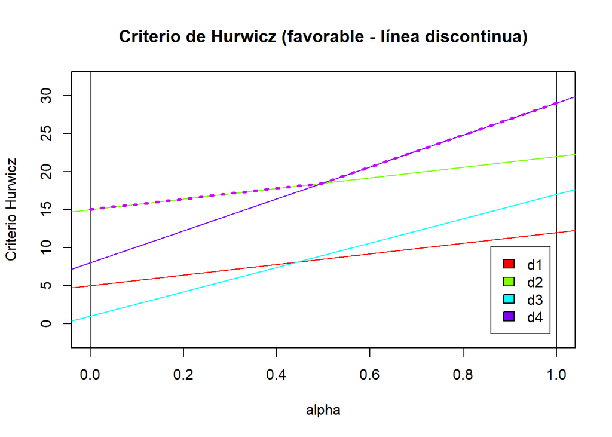

```r
dibuja.criterio.Hurwicz(X, favorable = TRUE)
```

**Situación desfavorable**

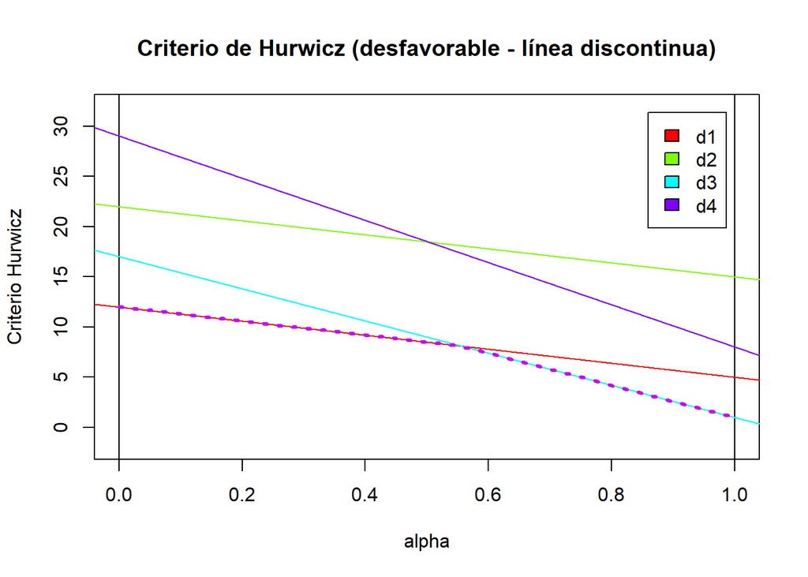

```r
dibuja.criterio.Hurwicz(X, favorable = FALSE)
```

**Interpretación de los gráficos**

En el caso de situación favorable, la alternativa óptima depende del grado de optimismo. Para valores de $\alpha$ más pequeños que 0.5 se selecciona $d_2$, mientras que para valores superiores se selecciona $d_4$. Cuando $\alpha=0.5$, ambas alternativas presentan la misma valoración, por lo que son óptimas.

En situación desfavorable, la alternativa óptima es $d_1$ para valores de $\alpha$ inferiores a $5/9$, mientras que para valores superiores es $d_3$. Para $\alpha=5/9$ ambas alternativas empatan.

Todo esto demuestra que la elección de la alternativa óptima puede cambiar en función del grado de optimismo del decisor.

### Criterio de Savage

El criterio de Savage (también conocido como Minimax del arrepentimiento) selecciona la **alternativa que minimiza el máximo arrepentimiento posible**.

Para aplicarlo, se tiene que construir una matriz de arrepentimientos comparando cada resultado con el mejor valor de su correspondiente estado de la naturaleza.

**Situación favorable**

El arrepentimiento se calcula como:

$$r_{ij}=\max_k x_{kj}-x_{ij}$$

**Situación desfavorable**

El arrepentimiento se calcula como:

$$r_{ij}=x_{ij}-\min_k x_{kj}$$

En *ambos casos* se selecciona la *alternativa que minimiza el máximo arrepentimiento*:

$$S=\min_i\left\{\max_j r_{ij}\right\}$$

Calculo ambos casos utilizando la función `criterio.Savage()`:

```r
savage_fav <- criterio.Savage(X, favorable = TRUE)
savage_desfav <- criterio.Savage(X, favorable = FALSE)

# Matriz de arrepentimientos favorable
knitr::kable(
  savage_fav$Pesos,
  caption = "Matriz de arrepentimientos en situación favorable"
)
```

Matriz de arrepentimientos en situación favorable

|  | e1 | e2 | e3 |
| --- | --- | --- | --- |
| d1 | 11 | 13 | 17 |
| d2 | 0 | 0 | 14 |
| d3 | 15 | 8 | 12 |
| d4 | 8 | 1 | 0 |

```r
# Matriz de arrepentimientos desfavorable
knitr::kable(
  savage_desfav$Pesos,
  caption = "Matriz de arrepentimientos en situación desfavorable"
)
```

Matriz de arrepentimientos en situación desfavorable

|  | e1 | e2 | e3 |
| --- | --- | --- | --- |
| d1 | 4 | 0 | 0 |
| d2 | 15 | 13 | 3 |
| d3 | 0 | 5 | 5 |
| d4 | 7 | 12 | 17 |

```r
# Valoración de las alternativas
tabla_savage <- data.frame(
  Alternativa = rownames(X),
  Favorable = as.numeric(savage_fav$ValorAlternativas),
  Desfavorable = as.numeric(savage_desfav$ValorAlternativas)
)

knitr::kable(
  tabla_savage,
  col.names = c("Alternativa", "Favorable", "Desfavorable"),
  caption = "Arrepentimiento máximo de cada alternativa"
)
```

Arrepentimiento máximo de cada alternativa

| Alternativa | Favorable | Desfavorable |
| --- | --- | --- |
| d1 | 17 | 4 |
| d2 | 14 | 15 |
| d3 | 15 | 5 |
| d4 | 8 | 17 |

En situación favorable, la alternativa óptima es $d_4$,porqueque presenta el menor arrepentimiento máximo, que es igual a 8.

En situación desfavorable, la alternativa óptima es $d_1$, ya que presenta el menor arrepentimiento máximo, que es igual a 4.

Por tanto, el criterio de Savage selecciona alternativas diferentes en ambas situaciones.

### Criterio de Laplace

El criterio de Laplace supone que **todos los estados de la naturaleza son equiprobables**. Por tanto, asigna la misma probabilidad a cada estado y calcula la media aritmética de los resultados de cada alternativa:

$$L_i=\frac{1}{n}\sum_{j=1}^{n}x_{ij}$$

En situación favorable se selecciona la *alternativa con mayor media*, mientras que en situación desfavorable se selecciona aquella que presenta la *menor media*.

Calculamos ambos casos utilizando la función `criterio.Laplace()`:

```r
laplace_fav <- criterio.Laplace(X, favorable = TRUE)
laplace_desfav <- criterio.Laplace(X, favorable = FALSE)

tabla_laplace <- data.frame(
  Alternativa = rownames(X),
  Favorable = as.numeric(laplace_fav$ValorAlternativas),
  Desfavorable = as.numeric(laplace_desfav$ValorAlternativas)
)

knitr::kable(
  tabla_laplace,
  digits = 3,
  col.names = c("Alternativa", "Favorable", "Desfavorable"),
  caption = "Valoración de las alternativas según el criterio de Laplace"
)
```

Valoración de las alternativas según el criterio de Laplace

| Alternativa | Favorable | Desfavorable |
| --- | --- | --- |
| d1 | 8.667 | 8.667 |
| d2 | 17.667 | 17.667 |
| d3 | 10.667 | 10.667 |
| d4 | 19.333 | 19.333 |

En situación favorable, la alternativa óptima es $d_4$, porque presenta la mayor media, con un valor aproximado de 19.333.

En situación desfavorable, la alternativa óptima es $d_1$, debido a que presenta la menor media, con un valor aproximado de 8.667.

### Criterio de Punto Ideal

El criterio de Punto Ideal consiste en construir un vector formado por los mejores resultados de cada estado de la naturaleza y seleccionar la **alternativa cuya distancia euclídea a dicho punto sea mínima**.

La distancia euclídea se calcula mediante:

$$D_i=\sqrt{\sum_{j=1}^{n}(x_{ij}-x_j^*)^2}$$

donde $x_j^*$ representa el resultado ideal del estado $e_j$.

**Situación favorable**

El punto ideal está formado por el *máximo de cada columna de la tabla*:

$$I_F=(16,22,29)$$

**Situación desfavorable**

El punto ideal está formado por el *mínimo de cada columna*:

$$I_D=(1,9,12)$$

Calculamos las distancias utilizando la función `criterio.PuntoIdeal()`:

```r
ideal_fav <- criterio.PuntoIdeal(X, favorable = TRUE)
ideal_desfav <- criterio.PuntoIdeal(X, favorable = FALSE)

tabla_ideal <- data.frame(
  Alternativa = rownames(X),
  Favorable = as.numeric(ideal_fav$ValorAlternativas),
  Desfavorable = as.numeric(ideal_desfav$ValorAlternativas)
)

knitr::kable(
  tabla_ideal,
  digits = 3,
  col.names = c("Alternativa", "Favorable", "Desfavorable"),
  caption = "Distancias euclídeas al Punto Ideal"
)
```

Distancias euclídeas al Punto Ideal

| Alternativa | Favorable | Desfavorable |
| --- | --- | --- |
| d1 | 24.062 | 4.000 |
| d2 | 14.000 | 20.075 |
| d3 | 20.809 | 7.071 |
| d4 | 8.062 | 21.954 |

En situación favorable, la alternativa óptima es $d_4$, ya que presenta la menor distancia al punto ideal, aproximadamente 8.062. En situación desfavorable, la alternativa óptima es $d_1$, cuya distancia al punto ideal es 4. Por tanto, este criterio selecciona alternativas distintas según se consideren beneficios o costes.

## Respuestas a las preguntas

**a) Verdadera.** En situación favorable, Wald selecciona $d_2$, ya que presenta el mayor de los mínimos, con un valor de 15.

**b) Falsa.** El criterio Optimista en situación favorable selecciona $d_4$, y no $d_3$, puesto que presenta el mayor resultado posible, igual a 29.

**d) Falsa.** El criterio de Savage selecciona $d_4$ en situación favorable y $d_1$ en situación desfavorable, por lo que las alternativas óptimas son distintas.

**e) Verdadera.** En situación desfavorable, tanto Laplace como Punto Ideal seleccionan la alternativa $d_1$.

# Problema 2

## Enunciado

El entrenador de un equipo de fútbol debe decidir en qué posición poner a jugar a un joven futbolista de su plantilla para el próximo partido. Se trata de un jugador capaz de desenvolverse en diferentes posiciones de ataque, pero cuyo rendimiento puede variar en función del planteamiento táctico del equipo rival.

Se contemplan cuatro alternativas:

- $d_1$: **Extremo izquierdo.** Jugar por la banda izquierda, tratando de generar ocasiones de gol desde esa zona.
- $d_2$: **Extremo derecho.** Desempeñar una función similar pero por la banda derecha.
- $d_3$: **Mediapunta.** Situarse por detrás del delantero, participando en la creación de jugadas de ataque.
- $d_4$: **Segundo delantero.** Jugar cerca del delantero, participando más directamente en las ocasiones de gol.

Sin embargo, el entrenador no conoce cómo planteará el partido el equipo contrario. Se consideran tres posibles estados de la naturaleza, según el estilo de juego del rival:

- $e_1$: **Defensa cerrada.** El rival acumula jugadores cerca de su portería, dejando pocos espacios para atacar.
- $e_2$: **Presión alta.** El rival intenta recuperar el balón cerca del área contraria, dificultando la salida del balón.
- $e_3$: **Partido abierto.** Ambos equipos disponen de espacios para atacar y se generan más oportunidades ofensivas.

A partir de las características del jugador, el entrenador ha estimado su posible rendimiento ofensivo en cada situación mediante una puntuación de 0 a 100, donde los valores más elevados indican un mejor rendimiento. Las valoraciones se recogen en la siguiente tabla:

| Posición | $e_1$ | $e_2$ | $e_3$ |
| --- | --- | --- | --- |
| $d_1$: Extremo izquierdo | 84 | 50 | 54 |
| $d_2$: Extremo derecho | 71 | 73 | 69 |
| $d_3$: Mediapunta | 61 | 79 | 83 |
| $d_4$: Segundo delantero | 44 | 72 | 96 |

*Nota: Como no se conocen las probabilidades de los distintos planteamientos del rival, el entrenador debe tomar una decisión bajo incertidumbre.*

Considerando una **situación favorable**, en la que se pretende maximizar el rendimiento del jugador, se aplicarán los criterios de Wald, Optimista, Hurwicz, Savage, Laplace y Punto Ideal. Para el criterio de Hurwicz se utilizará un coeficiente de optimismo $\alpha=0.5$.

Determina cuáles de las siguientes afirmaciones son verdaderas:

1. Según el criterio de Wald, la mejor opción es alinear al jugador como extremo derecho ($d_2$).
2. El criterio Optimista selecciona la posición de extremo izquierdo ($d_1$), ya que es la que permite alcanzar el mayor rendimiento posible.
3. Para un coeficiente de optimismo $\alpha=0.5$, el criterio de Hurwicz selecciona la alternativa $d_3$.
4. El criterio de Savage selecciona la misma alternativa que el criterio de Wald.
5. Los criterios de Laplace y Punto Ideal coinciden en seleccionar la posición de mediapunta ($d_3$).

## Solución

Primero introducimos en R la tabla de decisión con las valoraciones estimadas para cada posición del jugador y cada posible planteamiento táctico del equipo rival.

```r
Y <- crea.tablaX(
  c(84, 50, 54,
    71, 73, 69,
    61, 79, 83,
    44, 72, 96),
  numalternativas = 4,
  numestados = 3
)

knitr::kable(
  Y,
  caption = "Tabla de decisión del problema 2"
)
```

Tabla de decisión del problema 2

|  | e1 | e2 | e3 |
| --- | --- | --- | --- |
| d1 | 84 | 50 | 54 |
| d2 | 71 | 73 | 69 |
| d3 | 61 | 79 | 83 |
| d4 | 44 | 72 | 96 |

### Aplicación de los criterios de decisión

Como las puntuaciones representan el rendimiento ofensivo estimado del jugador, nos encontramos ante una situación favorable, en la que se pretende maximizar los resultados.

Para resolver el problema se utiliza la función `criterio.Todos()`, que permite aplicar conjuntamente los seis criterios de decisión bajo incertidumbre. Para Hurwicz se considera un coeficiente de optimismo $\alpha=0.5$.

```r
resultados2 <- criterio.Todos(
  Y,
  alfa = 0.5,
  favorable = TRUE
)

knitr::kable(
  resultados2,
  caption = "Resultados de los criterios de decisión del problema 2"
)
```

Resultados de los criterios de decisión del problema 2

|  | e1 | e2 | e3 | Wald | Optimista | Hurwicz | Savage | Laplace | Punto Ideal | Veces Optima |
| --- | --- | --- | --- | --- | --- | --- | --- | --- | --- | --- |
| d1 | 84 | 50 | 54 | 50 | 84 | 67 | 42 | 62.67 | 51.04 | 0 |
| d2 | 71 | 73 | 69 | 69 | 73 | 71 | 27 | 71.00 | 30.56 | 1 |
| d3 | 61 | 79 | 83 | 61 | 83 | 72 | 23 | 74.33 | 26.42 | 4 |
| d4 | 44 | 72 | 96 | 44 | 96 | 70 | 40 | 70.67 | 40.61 | 1 |
| iAlt.Opt (fav.) | – | – | – | d2 | d4 | d3 | d3 | d3 | d3 | d3 |

## Preguntas

**a) Verdadera.** El criterio de Wald selecciona la alternativa $d_2$ (extremo derecho), ya que presenta el mayor rendimiento mínimo, con una puntuación de 69.

**b) Falsa.** El criterio Optimista selecciona la alternativa $d_4$ (segundo delantero), porque permite alcanzar el mayor rendimiento posible, con una puntuación de 96.

**c) Verdadera.** Para $\alpha=0.5$, el criterio de Hurwicz selecciona la alternativa $d_3$ (mediapunta), ya que presenta la mayor valoración, igual a 72.

**d) Falsa.** El criterio de Savage selecciona la alternativa $d_3$ (mediapunta), mientras que Wald selecciona $d_2$ (extremo derecho). Por tanto, ambos criterios no coinciden.

**e) Verdadera.** Los criterios de Laplace y Punto Ideal coinciden en seleccionar la alternativa $d_3$ (mediapunta), que presenta el mayor rendimiento medio y la menor distancia al punto ideal respectivamente.

Por tanto, las afirmaciones verdaderas son **a), c) y e)**.

# Problema 3

## Enunciado

Se considera un problema de decisión bajo incertidumbre con cuatro alternativas de decisión, $d_1,d_2,d_3,d_4$, y tres posibles estados de la naturaleza, $e_1,e_2,e_3$, cuya matriz de valores numéricos es la siguiente:

| Alternativas | $e_1$ | $e_2$ | $e_3$ |
| --- | --- | --- | --- |
| $d_1$ | 16 | 30 | -4 |
| $d_2$ | 25 | 17 | 9 |
| $d_3$ | 24 | 29 | -5 |
| $d_4$ | 2 | 32 | 0 |

Se pide analizar el problema aplicando los criterios de decisión bajo incertidumbre estudiados (Wald, optimista, Savage, Laplace y Punto Ideal), considerando dos situaciones:

- **Situación favorable:** los valores de la matriz representan beneficios que se desean maximizar.  
- **Situación desfavorable:** los valores representan costes netos que se desean minimizar.

Para el criterio de Hurwicz se utilizará un coeficiente de optimismo de $\alpha=0.5$.

## Solución

Introducimos la matriz de decisión utilizando la función `crea.tablaX()`.

```r
tb01 = crea.tablaX(
  c(16,30,-4,
    25,17,9,
    24,29,-5,
    2,32,0),
  numalternativas = 4,
  numestados = 3
)

tb01
```

```
   e1 e2 e3
d1 16 30 -4
d2 25 17  9
d3 24 29 -5
d4  2 32  0
```

### Situación favorable:

Consideramos que los valores de la matriz representan BENEFICIOS, por lo que nuestro objetivo es MAXIMIZAR los resultados.

#### Criterio de Wald

```r
criterio.Wald(tb01, favorable = TRUE)
```

```
$criterio
[1] "Wald"

$metodo
[1] "favorable"

$tablaX
   e1 e2 e3
d1 16 30 -4
d2 25 17  9
d3 24 29 -5
d4  2 32  0

$ValorAlternativas
d1 d2 d3 d4
-4  9 -5  0

$ValorOptimo
[1] 9

$AlternativaOptima
d2
 2
```

**Interpretación:** El criterio de Wald adopta una actitud pesimista, considerando el peor resultado posible de cada alternativa. En este caso, la alternativa óptima es $d_2$, pues presenta el mayor beneficio mínimo, igual a 9, siendo así la opción más favorable en el escenario más desfavorable.

#### Criterio Optimista

```r
criterio.Optimista(tb01, favorable = TRUE)
```

```
$criterio
[1] "Optimista"

$metodo
[1] "favorable"

$tablaX
   e1 e2 e3
d1 16 30 -4
d2 25 17  9
d3 24 29 -5
d4  2 32  0

$ValorAlternativas
d1 d2 d3 d4
30 25 29 32

$ValorOptimo
[1] 32

$AlternativaOptima
d4
 4
```

**Interpretación:** El criterio Optimista considera únicamente el mejor resultado posible de cada alternativa, sin tener en cuenta los resultados desfavorables. En este caso, la alternativa óptima es $d_4$, pues es la que puede alcanzar el mayor beneficio de toda la matriz (32).

#### Criterio de Hurwicz

Utilizamos un coeficiente de optimismo de $\alpha=0.5$.

```r
criterio.Hurwicz(tb01, alfa = 0.5, favorable = TRUE)
```

```
$criterio
[1] "Hurwicz"

$alfa
[1] 0.5

$metodo
[1] "favorable"

$tablaX
   e1 e2 e3
d1 16 30 -4
d2 25 17  9
d3 24 29 -5
d4  2 32  0

$ValorAlternativas
d1 d2 d3 d4
13 17 12 16

$ValorOptimo
[1] 17

$AlternativaOptima
d2
 2
```

**Interpretación:** La alternativa óptima es $d_2$, con una valoración de 17. Al utilizar $\alpha=0.5$, se asigna el mismo peso al mejor y al peor resultado de cada alternativa.

Sin embargo, la decisión puede variar dependiendo del grado de optimismo del decisor. Para comprobarlo, representamos gráficamente cómo cambia la valoración de cada alternativa cuando $\alpha$ toma valores entre 0 y 1.

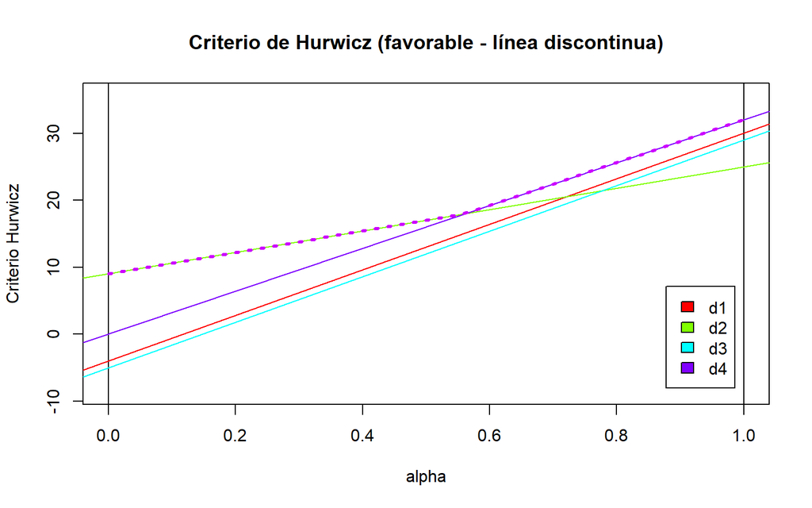

Criterio de Hurwicz en situación favorable

```r
dibuja.criterio.Hurwicz(tb01, favorable = TRUE)
```

Como podemos observar, cuanto menor es $\alpha$, más pesimista es el criterio, hasta coincidir con el criterio de Wald cuando $\alpha=0$. Por el contrario, al aumentar $\alpha$, el criterio se vuelve más optimista, llegando a coincidir con el criterio Optimista cuando $\alpha=1$.

Para determinar con mayor precisión los intervalos de $\alpha$ en los que cada alternativa resulta óptima, utilizamos la siguiente función:

```r
dibuja.criterio.Hurwicz_Intervalos(
  tb01,
  favorable = TRUE,
  mostrarGrafico = FALSE
)
```

```
$AltOptimas
[1] 2 4

$PuntosDeCorte
[1] 0.562

$IntervalosAlfa
     Intervalo       Alternativa
[1,] "( 0 , 0.562 )" "2"
[2,] "( 0.562 , 1 )" "4"
```

**Interpretación:** Los resultados muestran que la alternativa óptima depende del valor de $\alpha$:

- Para $0 \leq \alpha < 0.5625$, la alternativa óptima es $d_2$.
- Para $\alpha=0.5625$, las alternativas $d_2$ y $d_4$ son igualmente óptimas.
- Para $0.5625 < \alpha \leq 1$, la alternativa óptima es $d_4$.

Por tanto, como en nuestro problema hemos utilizado $\alpha=0.5$, la alternativa óptima sigue siendo $d_2$.

#### Criterio de Savage

```r
criterio.Savage(tb01, favorable = TRUE)
```

```
$criterio
[1] "Savage"

$metodo
[1] "favorable"

$tablaX
   e1 e2 e3
d1 16 30 -4
d2 25 17  9
d3 24 29 -5
d4  2 32  0

$Mejores
e1 e2 e3
25 32  9

$Pesos
   e1 e2 e3
d1  9  2 13
d2  0 15  0
d3  1  3 14
d4 23  0  9

$ValorAlternativas
d1 d2 d3 d4
13 15 14 23

$ValorOptimo
[1] 13

$AlternativaOptima
d1
 1
```

**Interpretación:** Este criterio selecciona la alternativa que minimiza el máximo arrepentimiento posible. Por eso, la alternativa óptima es $d_1$, cuyo máximo arrepentimiento es 13.

#### Criterio de Laplace

```r
criterio.Laplace(tb01, favorable = TRUE)
```

```
$criterio
[1] "Laplace"

$metodo
[1] "favorable"

$tablaX
   e1 e2 e3
d1 16 30 -4
d2 25 17  9
d3 24 29 -5
d4  2 32  0

$ValorAlternativas
      d1       d2       d3       d4
14.00000 17.00000 16.00000 11.33333

$ValorOptimo
[1] 17

$AlternativaOptima
d2
 2
```

**Interpretación:** Este criterio considera que todos los estados de la naturaleza son equiprobables. Por ello, la alternativa óptima es $d_2$, con un *beneficio medio* de 17.

#### Criterio del Punto Ideal

```r
criterio.PuntoIdeal(tb01, favorable = TRUE)
```

```
$criterio
[1] "Punto Ideal"

$metodo
[1] "favorable"

$tablaX
   e1 e2 e3
d1 16 30 -4
d2 25 17  9
d3 24 29 -5
d4  2 32  0

$Mejores
e1 e2 e3
25 32  9

$ValorAlternativas
      d1       d2       d3       d4
15.93738 15.00000 14.35270 24.69818

$ValorOptimo
[1] 14.3527

$AlternativaOptima
d3
 3
```

**Interpretación:** La alternativa óptima es $d_3$, puesto que presenta la menor distancia euclídea respecto al punto ideal, formado por los mayores beneficios de cada estado de la naturaleza.

### Situación desfavorable:

Consideramos ahora que los valores de la matriz representan COSTES, por lo que el objetivo es MINIMIZARLOS.

#### Criterio de Wald

```r
criterio.Wald(tb01, favorable = FALSE)
```

```
$criterio
[1] "Wald"

$metodo
[1] "desfavorable"

$tablaX
   e1 e2 e3
d1 16 30 -4
d2 25 17  9
d3 24 29 -5
d4  2 32  0

$ValorAlternativas
d1 d2 d3 d4
30 25 29 32

$ValorOptimo
[1] 25

$AlternativaOptima
d2
 2
```

**Interpretación:** Este criterio considera el peor coste posible de cada alternativa. La óptima es $d_2$, pues presenta el menor coste máximo (25).

#### Criterio Optimista

```r
criterio.Optimista(tb01, favorable = FALSE)
```

```
$criterio
[1] "Optimista"

$metodo
[1] "desfavorable"

$tablaX
   e1 e2 e3
d1 16 30 -4
d2 25 17  9
d3 24 29 -5
d4  2 32  0

$ValorAlternativas
d1 d2 d3 d4
-4  9 -5  0

$ValorOptimo
[1] -5

$AlternativaOptima
d3
 3
```

**Interpretación:** La alternativa óptima es $d_3$, porque presenta el menor coste posible, igual a -5.

#### Criterio de Hurwicz

Utilizamos nuevamente un coeficiente de optimismo de $\alpha=0.5$.

```r
criterio.Hurwicz(tb01, alfa = 0.5, favorable = FALSE)
```

```
$criterio
[1] "Hurwicz"

$alfa
[1] 0.5

$metodo
[1] "desfavorable"

$tablaX
   e1 e2 e3
d1 16 30 -4
d2 25 17  9
d3 24 29 -5
d4  2 32  0

$ValorAlternativas
d1 d2 d3 d4
13 17 12 16

$ValorOptimo
[1] 12

$AlternativaOptima
d3
 3
```

**Interpretación:** La alternativa óptima es $d_3$, con una valoración de 12, al ponderar por igual el menor y el mayor coste posible de cada alternativa.

Representamos gráficamente cómo varía la decisión óptima en función de $\alpha$, considerando ahora una situación desfavorable (COSTES).

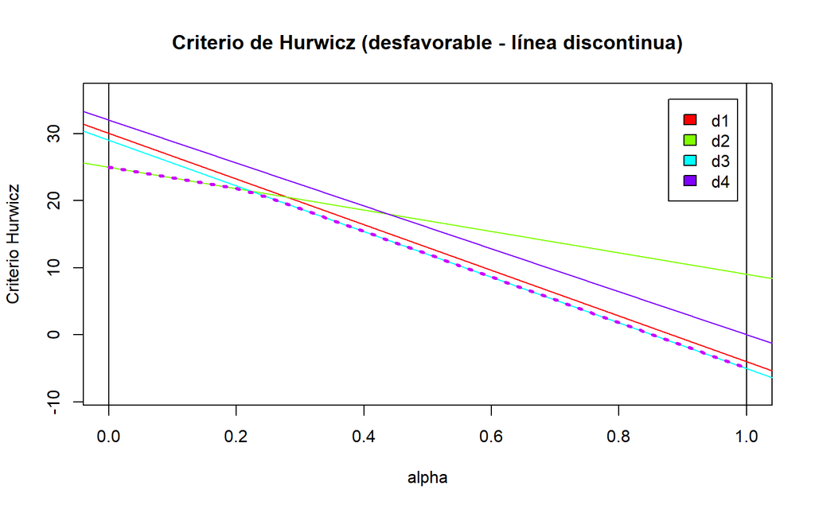

Criterio de Hurwicz en situación desfavorable

```r
dibuja.criterio.Hurwicz(tb01, favorable = FALSE)
```

Para conocer con mayor precisión los intervalos de $\alpha$ en los que cada alternativa resulta óptima, utilizamos:

```r
dibuja.criterio.Hurwicz_Intervalos(
  tb01,
  favorable = FALSE,
  mostrarGrafico = FALSE
)
```

```
$AltOptimas
[1] 2 3

$PuntosDeCorte
[1] 0.222

$IntervalosAlfa
     Intervalo       Alternativa
[1,] "( 0 , 0.222 )" "2"
[2,] "( 0.222 , 1 )" "3"
```

**Interpretación:** Para valores de $\alpha$ inferiores a 0.222, la alternativa óptima es $d_2$; para valores superiores, es $d_3$. En el punto de corte ambas empatan. Por tanto, con $\alpha=0.5$, seguimos eligiendo $d_3$.

#### Criterio de Savage

```r
criterio.Savage(tb01, favorable = FALSE)
```

```
$criterio
[1] "Savage"

$metodo
[1] "desfavorable"

$tablaX
   e1 e2 e3
d1 16 30 -4
d2 25 17  9
d3 24 29 -5
d4  2 32  0

$Mejores
e1 e2 e3
 2 17 -5

$Pesos
   e1 e2 e3
d1 14 13  1
d2 23  0 14
d3 22 12  0
d4  0 15  5

$ValorAlternativas
d1 d2 d3 d4
14 23 22 15

$ValorOptimo
[1] 14

$AlternativaOptima
d1
 1
```

**Interpretación:** La alternativa óptima es $d_1$, cuyo máximo arrepentimiento es 14. Esta alternativa minimiza el máximo arrepentimiento posible.

#### Criterio de Laplace

```r
criterio.Laplace(tb01, favorable = FALSE)
```

```
$criterio
[1] "Laplace"

$metodo
[1] "desfavorable"

$tablaX
   e1 e2 e3
d1 16 30 -4
d2 25 17  9
d3 24 29 -5
d4  2 32  0

$ValorAlternativas
      d1       d2       d3       d4
14.00000 17.00000 16.00000 11.33333

$ValorOptimo
[1] 11.33333

$AlternativaOptima
d4
 4
```

**Interpretación:** La alternativa óptima es $d_4$, ya que presenta el menor *coste medio*, aproximadamente igual a 11.33.

#### Criterio del Punto Ideal

```r
criterio.PuntoIdeal(tb01, favorable = FALSE)
```

```
$criterio
[1] "Punto Ideal"

$metodo
[1] "desfavorable"

$tablaX
   e1 e2 e3
d1 16 30 -4
d2 25 17  9
d3 24 29 -5
d4  2 32  0

$Mejores
e1 e2 e3
 2 17 -5

$ValorAlternativas
      d1       d2       d3       d4
19.13113 26.92582 25.05993 15.81139

$ValorOptimo
[1] 15.81139

$AlternativaOptima
d4
 4
```

**Interpretación:** La alternativa óptima es $d_4$, puesto que presenta la menor distancia euclídea respecto al punto ideal, formado por los menores costes de cada estado de la naturaleza.

### Comparación de los resultados

Las alternativas óptimas obtenidas mediante los distintos criterios son:

| Criterio | Favorable | Desfavorable |
| --- | --- | --- |
| Wald | $d_2$ | $d_2$ |
| Optimista | $d_4$ | $d_3$ |
| Hurwicz ($\alpha=0.5$) | $d_2$ | $d_3$ |
| Savage | $d_1$ | $d_1$ |
| Laplace | $d_2$ | $d_4$ |
| Punto Ideal | $d_3$ | $d_4$ |

Los resultados muestran que la elección de la alternativa óptima **depende del criterio utilizado** y de si los **valores se interpretan como beneficios o como costes**.

En situación favorable, la alternativa que más veces ha sido recomendada es $d_2$, seleccionada por tres criterios: Wald, Hurwicz y Laplace.

En situación desfavorable, las decisiones se reparten entre las cuatro alternativas.

Por tanto, no existe una única alternativa recomendada por todos los métodos, lo que pone de manifiesto la **importancia** de la **actitud y postura del decisor ante la incertidumbre**.

## Preguntas

De acuerdo con los resultados obtenidos al aplicar los distintos criterios de decisión bajo incertidumbre, **seleccione todas las afirmaciones verdaderas y justifique cada respuesta, explicando por qué es verdadera o falsa.**

1. En situación favorable, el criterio de Wald selecciona la alternativa $d_2$.
2. En situación favorable, los criterios Optimista y de Hurwicz, con $\alpha=0.5$, seleccionan la misma alternativa.
3. El criterio de Savage selecciona la alternativa $d_1$ tanto en situación favorable como desfavorable.
4. En situación desfavorable, el criterio de Laplace selecciona la alternativa $d_2$.
5. El criterio del Punto Ideal selecciona alternativas diferentes en las situaciones favorable y desfavorable.

## Respuestas a las preguntas:

**a) Verdadera.** En situación favorable, el criterio de Wald selecciona la alternativa $d_2$, ya que su beneficio mínimo es 9, el mayor de los mínimos de todas las alternativas (‘maxmin’). Por tanto, es la opción que ofrece el mejor resultado en el escenario más desfavorable.

**b) Falsa.** El criterio Optimista selecciona $d_4$, puesto que alcanza el mayor beneficio posible, igual a 32. Sin embargo, el criterio de Hurwicz, con $\alpha=0.5$, selecciona $d_2$, cuya valoración es 17. Por tanto, ambos criterios no coinciden.

**c) Verdadera.** El criterio de Savage selecciona $d_1$ en ambas situaciones, ya que es la alternativa que minimiza el máximo arrepentimiento. En situación favorable, su máximo arrepentimiento es 13, mientras que en situación desfavorable es 14.

**d) Falsa.** En situación desfavorable, el criterio de Laplace selecciona $d_4$, ya que presenta el menor coste medio, aproximadamente igual a 11.33. En cambio, $d_2$ tiene un coste medio de 17, por lo que no resulta óptima.

**e) Verdadera.** El criterio del Punto Ideal selecciona $d_3$ en situación favorable y $d_4$ en situación desfavorable, puesto que son las alternativas que presentan la menor distancia euclídea respecto al punto ideal de cada situación.

Por tanto, **las afirmaciones verdaderas son a), c) y e)**.

# Problema 4

## Enunciado

Una empresa española dedicada a la producción y comercialización de jamón ibérico está estudiando la posibilidad de expandirse internacionalmente, introduciendo sus productos en un nuevo mercado.

Tras analizar diferentes posibilidades, la empresa ha seleccionado cuatro países candidatos: **Francia, Alemania, México y Japón**. Sin embargo, desconoce cuál será la demanda de sus productos durante el primer año, por lo que contempla tres posibles estados de la naturaleza: demanda baja, moderada o alta.

Los beneficios netos estimados para el primer año, una vez descontados los costes previstos de producción, transporte, distribución y comercialización, se recogen en la siguiente matriz (valores hipotéticos expresados en miles de euros):

| Alternativas | $e_1$ | $e_2$ | $e_3$ |
| --- | --- | --- | --- |
| $d_1$: Francia | 16 | 30 | 44 |
| $d_2$: Alemania | 22 | 27 | 35 |
| $d_3$: México | -6 | 24 | 60 |
| $d_4$: Japón | -12 | 20 | 74 |

Donde:

- $e_1$: demanda baja.
- $e_2$: demanda moderada.
- $e_3$: demanda alta.

Los valores negativos representan posibles pérdidas económicas durante el primer año.

**¿En qué país debería introducir sus productos la empresa?**

Para responder a esta cuestión, se pide aplicar los criterios de decisión bajo incertidumbre estudiados en la asignatura mediante la función conjunta de R. Se utilizará un coeficiente de optimismo de $\alpha=0.5$ para el criterio de Hurwicz.

## Solución

En este problema nos encontramos ante una situación **favorable**, pues la matriz representan BENEFICIOS NETOS y, por tanto, nuestro objetivo es MAXIMIZARLOS.

Introducimos la matriz de decisión utilizando la función `crea.tablaX()`:

```r
tb02 = crea.tablaX(
  c(16,30,44,
    22,27,35,
    -6,24,60,
    -12,20,74),
  numalternativas = 4,
  numestados = 3,
  nb_alternativas = c("Francia","Alemania","Mexico","Japon"),
  nb_estados = c("Demanda baja","Demanda moderada","Demanda alta")
)

tb02
```

```
         Demanda baja Demanda moderada Demanda alta
Francia            16               30           44
Alemania           22               27           35
Mexico             -6               24           60
Japon             -12               20           74
```

A continuación, aplicamos conjuntamente todos los criterios de decisión bajo incertidumbre mediante la función `criterio.Todos()`, utilizando un coeficiente de optimismo de $\alpha=0.5$.

```r
criterio.Todos(tb02, alfa = 0.5, favorable = TRUE)
```

```
                Demanda baja Demanda moderada Demanda alta     Wald Optimista
Francia                   16               30           44       16        44
Alemania                  22               27           35       22        35
Mexico                    -6               24           60       -6        60
Japon                    -12               20           74      -12        74
iAlt.Opt (fav.)           --               --           -- Alemania     Japon
                Hurwicz Savage Laplace Punto Ideal  Veces Optima
Francia            30.0     30   30.00       30.59             2
Alemania           28.5     39   28.00       39.12             1
Mexico             27.0     28   26.00       31.87             1
Japon              31.0     34   27.33       35.44             2
iAlt.Opt (fav.)   Japon Mexico Francia     Francia Francia,Japon
```

### Interpretación de los resultados

- **Criterio de Wald:** Tomando la postura pesimista, la opción óptima es **Alemania**, pues garantiza el mayor beneficio mínimo, igual a 22.000 €. Es, por tanto, el país que ofrece mayor seguridad ante un escenario de demanda baja.
- **Criterio Optimista:** Siendo optimistas, la mejor opción sería **Japón**, ya que podría alcanzar el mayor beneficio de toda la matriz, igual a 74.000 €, si la demanda fuese alta. Sin embargo, también presenta la mayor pérdida potencial, por lo que se trata de una alternativa muy arriesgada.
- **Criterio de Hurwicz:** Utilizando $\alpha=0.5$, la opción óptima es **Japón**, con una valoración de 31.000 €, ligeramente superior a la de Francia (30.000 €).
- **Criterio de Savage:** La opción óptima es **México**, cuyo arrepentimiento máximo es de 28.000 €, el menor entre los cuatro países.
- **Criterio de Laplace:** Considerando todos los estados de la naturaleza equiprobables, se calcula el beneficio medio de cada alternativa. En este caso, la opción óptima es **Francia**, con un beneficio medio de 30.000 €, superior al de los demás países.
- **Criterio del Punto Ideal:** La alternativa óptima es **Francia**, cuya distancia al punto ideal es aproximadamente 30,59, la menor de las cuatro alternativas.

### Conclusión

Los resultados muestran que la decisión **depende** del criterio utilizado y, por tanto, de la **actitud de la empresa frente a la incertidumbre**.  
**Francia y Japón** son los países recomendados por un mayor número de criterios, con dos recomendaciones cada uno.  
Alemania sería la opción más adecuada para una empresa especialmente conservadora, mientras que Japón resultaría atractivo para una empresa dispuesta a asumir mayores riesgos con el objetivo de obtener beneficios elevados.  
Por otro lado, México sería la alternativa recomendada si la empresa desea minimizar el máximo arrepentimiento, mientras que Francia destacaría al considerar los beneficios medios o la proximidad al punto ideal.  
Así que para este caso, no existe una única alternativa recomendada por todos los criterios, y la decisión final dependerá de las preferencias y de la actitud de la empresa ante la incertidumbre.

## Preguntas

De acuerdo con los resultados obtenidos al aplicar los distintos criterios de decisión bajo incertidumbre, **seleccione todas las afirmaciones verdaderas y justifique cada respuesta, explicando por qué es verdadera o falsa.**

1. El criterio de Hurwicz, con un coeficiente de optimismo de $\alpha=0.5$, recomienda introducir los productos en Francia.
2. Según el criterio de Wald, Alemania es el país recomendado, ya que presenta el mayor beneficio mínimo.
3. El criterio de Laplace recomienda Japón, puesto que es el país que puede alcanzar el mayor beneficio posible.
4. Según el criterio de Savage, México es la alternativa que minimiza el máximo arrepentimiento.
5. El criterio del Punto Ideal recomienda Francia, al presentar la menor distancia euclídea respecto al punto ideal.

### Respuestas a las preguntas:

**a) Falsa.** Con $\alpha=0.5$, el criterio de Hurwicz selecciona Japón, cuya valoración es de 31.000 €, mientras que Francia obtiene 30.000 €. Por tanto, Francia no resulta óptima según este criterio.

**b) Verdadera.** El criterio de Wald selecciona Alemania, ya que su beneficio mínimo es de 22.000 €, superior al beneficio mínimo de los demás países. Por tanto, es la alternativa que garantiza el mejor resultado en el escenario más desfavorable.

**c) Falsa.** El criterio de Laplace selecciona Francia, que presenta el mayor beneficio medio, igual a 30.000 €. Japón es la alternativa elegida por el criterio Optimista, al alcanzar el mayor beneficio posible (74.000 €), pero su beneficio medio es inferior al de Francia.

**d) Verdadera.** El criterio de Savage selecciona México, ya que su máximo arrepentimiento es de 28.000 €, el menor de las cuatro alternativas.

**e) Verdadera.** El criterio del Punto Ideal selecciona Francia porque presenta la menor distancia euclídea respecto al punto ideal, formado por los mayores beneficios de cada estado de la naturaleza.

Por tanto, **las afirmaciones verdaderas son b), d) y e)**.

# Problema 5

## Enunciado

Una empresa dedicada a la fabricación de calzado debe decidir qué tipo de producto comercializar durante la próxima temporada. La demanda de sus productos depende de las condiciones climatológicas, que no pueden conocerse con certeza en el momento de tomar la decisión.

La empresa contempla tres alternativas de producción: **botas, zapatos y sandalias**. Asimismo, considera tres posibles estados de la naturaleza: una temporada **fría, templada o cálida**.

Tras realizar un estudio de mercado, la empresa ha obtenido las siguientes estimaciones de resultados económicos, expresadas en miles de euros:

```r
tb05 <- crea.tablaX(
  c(70, 25, 5,
    30, 45, 20,
    5, 20, 65),
  numalternativas = 3,
  numestados = 3
)

rownames(tb05) <- c("Botas", "Zapatos", "Sandalias")
colnames(tb05) <- c("Frío", "Templado", "Cálido")

knitr::kable(tb05)
```

|  | Frío | Templado | Cálido |
| --- | --- | --- | --- |
| Botas | 70 | 25 | 5 |
| Zapatos | 30 | 45 | 20 |
| Sandalias | 5 | 20 | 65 |

Determine qué alternativa de producción resulta más conveniente aplicando los distintos criterios de decisión bajo incertidumbre. Realice el análisis considerando, por una parte, que los resultados económicos representan beneficios que se desean maximizar y, por otra, que representan costes que se pretenden minimizar. Para el criterio de Hurwicz, considere un índice de optimismo de $\alpha = 0.3$.

## Planteamiento

- **Decisor:** empresa fabricante de calzado.
- **Modelo:** decisión bajo incertidumbre, tanto favorable (maximización de beneficios) como desfavorable (minimización de costes).
- **Alternativas:**
  - d1 = Botas.
  - d2 = Zapatos.
  - d3 = Sandalias.
- **Estados de la naturaleza:**
  - e1 = Frío.
  - e2 = Templado.
  - e3 = Cálido.

La matriz de decisión está formada por los resultados económicos correspondientes a cada alternativa y estado de la naturaleza.

```r
tb05
```

```
          Frío Templado Cálido
Botas       70       25      5
Zapatos     30       45     20
Sandalias    5       20     65
```

## Solución

### Situación favorable: maximización de beneficios

Consideramos que los valores de la tabla representan beneficios, por lo que buscamos la alternativa que maximice el resultado según cada criterio.

#### Criterio de Wald

```r
criterio.Wald(tb05, favorable = TRUE)
```

```
$criterio
[1] "Wald"

$metodo
[1] "favorable"

$tablaX
          Frío Templado Cálido
Botas       70       25      5
Zapatos     30       45     20
Sandalias    5       20     65

$ValorAlternativas
    Botas   Zapatos Sandalias
        5        20         5

$ValorOptimo
[1] 20

$AlternativaOptima
Zapatos
      2
```

El criterio de Wald selecciona **zapatos**, ya que su beneficio mínimo es 20 mil euros, superior al beneficio mínimo de las otras dos alternativas.

#### Criterio Optimista

```r
criterio.Optimista(tb05, favorable = TRUE)
```

```
$criterio
[1] "Optimista"

$metodo
[1] "favorable"

$tablaX
          Frío Templado Cálido
Botas       70       25      5
Zapatos     30       45     20
Sandalias    5       20     65

$ValorAlternativas
    Botas   Zapatos Sandalias
       70        45        65

$ValorOptimo
[1] 70

$AlternativaOptima
Botas
    1
```

El criterio Optimista selecciona **botas**, ya que es la alternativa que puede proporcionar el mayor beneficio, con un valor de 70 mil euros.

#### Criterio de Hurwicz

```r
criterio.Hurwicz(tb05, alfa = 0.3, favorable = TRUE)
```

```
$criterio
[1] "Hurwicz"

$alfa
[1] 0.3

$metodo
[1] "favorable"

$tablaX
          Frío Templado Cálido
Botas       70       25      5
Zapatos     30       45     20
Sandalias    5       20     65

$ValorAlternativas
    Botas   Zapatos Sandalias
     24.5      27.5      23.0

$ValorOptimo
[1] 27.5

$AlternativaOptima
Zapatos
      2
```

Aplicando el criterio de Hurwicz con un índice de optimismo de $\alpha = 0.3$, la mejor alternativa es **zapatos**, con un valor de 27.5 mil euros.

Este criterio combina el mejor y el peor resultado de cada alternativa, teniendo en cuenta el grado de optimismo establecido.

#### Representación gráfica del criterio de Hurwicz

Para completar el análisis, representamos gráficamente cómo varía la valoración de las alternativas en función del índice de optimismo $\alpha$.

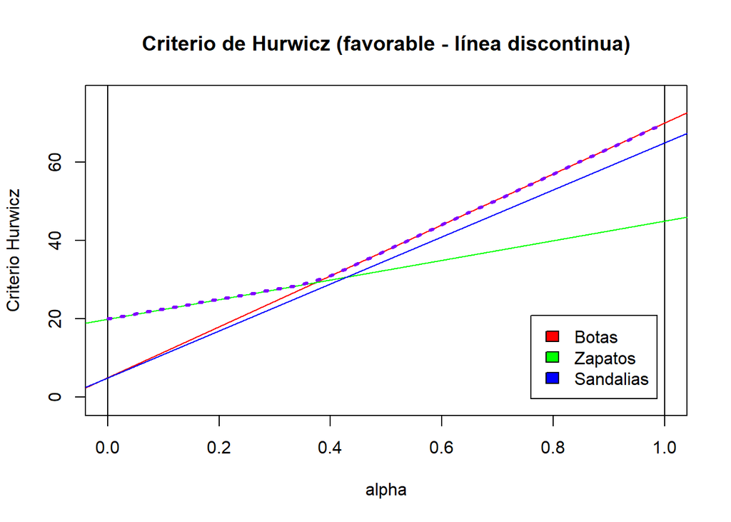

```r
dibuja.criterio.Hurwicz(tb05, favorable = TRUE)
```

La gráfica permite observar cómo cambia la valoración de botas, zapatos y sandalias cuando el índice de optimismo varía entre 0 y 1. De esta manera, podemos comparar visualmente las alternativas y comprobar cómo influye el grado de optimismo en la decisión.

#### Criterio de Savage

```r
criterio.Savage(tb05, favorable = TRUE)
```

```
$criterio
[1] "Savage"

$metodo
[1] "favorable"

$tablaX
          Frío Templado Cálido
Botas       70       25      5
Zapatos     30       45     20
Sandalias    5       20     65

$Mejores
    Frío Templado   Cálido
      70       45       65

$Pesos
          Frío Templado Cálido
Botas        0       20     60
Zapatos     40        0     45
Sandalias   65       25      0

$ValorAlternativas
    Botas   Zapatos Sandalias
       60        45        65

$ValorOptimo
[1] 45

$AlternativaOptima
Zapatos
      2
```

Según el criterio de Savage, la mejor alternativa es **zapatos**, ya que presenta el menor arrepentimiento máximo, con un valor de 45 mil euros.

#### Criterio de Laplace

```r
criterio.Laplace(tb05, favorable = TRUE)
```

```
$criterio
[1] "Laplace"

$metodo
[1] "favorable"

$tablaX
          Frío Templado Cálido
Botas       70       25      5
Zapatos     30       45     20
Sandalias    5       20     65

$ValorAlternativas
    Botas   Zapatos Sandalias
 33.33333  31.66667  30.00000

$ValorOptimo
[1] 33.33333

$AlternativaOptima
Botas
    1
```

El criterio de Laplace considera que todos los estados de la naturaleza son igualmente probables. La mejor alternativa es **botas**, con un beneficio medio aproximado de 33.33 mil euros.

#### Criterio del Punto Ideal

```r
criterio.PuntoIdeal(tb05, favorable = TRUE)
```

```
$criterio
[1] "Punto Ideal"

$metodo
[1] "favorable"

$tablaX
          Frío Templado Cálido
Botas       70       25      5
Zapatos     30       45     20
Sandalias    5       20     65

$Mejores
    Frío Templado   Cálido
      70       45       65

$ValorAlternativas
    Botas   Zapatos Sandalias
 63.24555  60.20797  69.64194

$ValorOptimo
[1] 60.20797

$AlternativaOptima
Zapatos
      2
```

Este criterio selecciona la alternativa que se encuentra a menor distancia del punto ideal, formado por los mejores resultados de cada estado de la naturaleza.

En este caso, la mejor alternativa es **zapatos**, con una distancia aproximada de 60.21.

### Situación desfavorable: minimización de costes

Ahora consideramos que los valores de la tabla representan costes económicos. Por tanto, el objetivo será seleccionar la alternativa que permita minimizar dichos costes.

#### Criterio de Wald

```r
criterio.Wald(tb05, favorable = FALSE)
```

```
$criterio
[1] "Wald"

$metodo
[1] "desfavorable"

$tablaX
          Frío Templado Cálido
Botas       70       25      5
Zapatos     30       45     20
Sandalias    5       20     65

$ValorAlternativas
    Botas   Zapatos Sandalias
       70        45        65

$ValorOptimo
[1] 45

$AlternativaOptima
Zapatos
      2
```

El criterio de Wald selecciona **zapatos**, ya que su coste máximo es de 45 mil euros, inferior al coste máximo de las demás alternativas.

#### Criterio Optimista

```r
criterio.Optimista(tb05, favorable = FALSE)
```

```
$criterio
[1] "Optimista"

$metodo
[1] "desfavorable"

$tablaX
          Frío Templado Cálido
Botas       70       25      5
Zapatos     30       45     20
Sandalias    5       20     65

$ValorAlternativas
    Botas   Zapatos Sandalias
        5        20         5

$ValorOptimo
[1] 5

$AlternativaOptima
    Botas Sandalias
        1         3
```

El criterio Optimista selecciona **botas y sandalias**, puesto que ambas alternativas pueden alcanzar el menor coste posible, de 5 mil euros.

En este caso, existe un empate entre las dos alternativas.

#### Criterio de Hurwicz

```r
criterio.Hurwicz(tb05, alfa = 0.3, favorable = FALSE)
```

```
$criterio
[1] "Hurwicz"

$alfa
[1] 0.3

$metodo
[1] "desfavorable"

$tablaX
          Frío Templado Cálido
Botas       70       25      5
Zapatos     30       45     20
Sandalias    5       20     65

$ValorAlternativas
    Botas   Zapatos Sandalias
     50.5      37.5      47.0

$ValorOptimo
[1] 37.5

$AlternativaOptima
Zapatos
      2
```

Con un índice de optimismo de $\alpha = 0.3$, el criterio de Hurwicz recomienda fabricar **zapatos**, con un coste ponderado de 37.5 mil euros.

#### Representación gráfica del criterio de Hurwicz

Para completar el análisis, representamos gráficamente cómo varía la valoración de las alternativas en función del índice de optimismo $\alpha$.

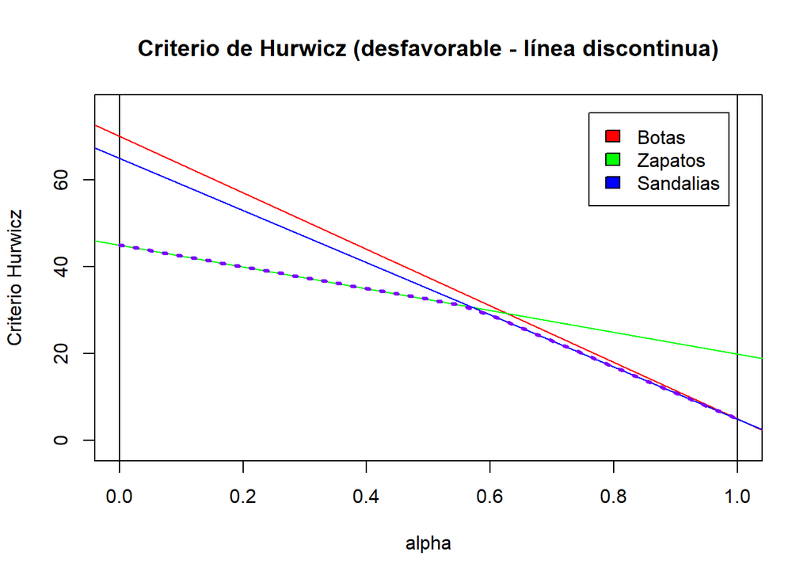

```r
dibuja.criterio.Hurwicz(tb05, favorable = FALSE)
```

La gráfica permite observar cómo cambia la valoración de botas, zapatos y sandalias cuando el índice de optimismo varía entre 0 y 1. En esta situación desfavorable, al tratarse de costes, se busca seleccionar la alternativa con el menor valor. De esta manera, podemos comparar visualmente las alternativas y comprobar cómo influye el grado de optimismo en la decisión.

#### Criterio de Savage

```r
criterio.Savage(tb05, favorable = FALSE)
```

```
$criterio
[1] "Savage"

$metodo
[1] "desfavorable"

$tablaX
          Frío Templado Cálido
Botas       70       25      5
Zapatos     30       45     20
Sandalias    5       20     65

$Mejores
    Frío Templado   Cálido
       5       20        5

$Pesos
          Frío Templado Cálido
Botas       65        5      0
Zapatos     25       25     15
Sandalias    0        0     60

$ValorAlternativas
    Botas   Zapatos Sandalias
       65        25        60

$ValorOptimo
[1] 25

$AlternativaOptima
Zapatos
      2
```

El criterio de Savage selecciona **zapatos**, ya que presenta el menor arrepentimiento máximo, con un valor de 25 mil euros.

#### Criterio de Laplace

```r
criterio.Laplace(tb05, favorable = FALSE)
```

```
$criterio
[1] "Laplace"

$metodo
[1] "desfavorable"

$tablaX
          Frío Templado Cálido
Botas       70       25      5
Zapatos     30       45     20
Sandalias    5       20     65

$ValorAlternativas
    Botas   Zapatos Sandalias
 33.33333  31.66667  30.00000

$ValorOptimo
[1] 30

$AlternativaOptima
Sandalias
        3
```

El criterio de Laplace recomienda fabricar **sandalias**, puesto que presenta el menor coste medio, de 30 mil euros.

#### Criterio del Punto Ideal

```r
criterio.PuntoIdeal(tb05, favorable = FALSE)
```

```
$criterio
[1] "Punto Ideal"

$metodo
[1] "desfavorable"

$tablaX
          Frío Templado Cálido
Botas       70       25      5
Zapatos     30       45     20
Sandalias    5       20     65

$Mejores
    Frío Templado   Cálido
       5       20        5

$ValorAlternativas
    Botas   Zapatos Sandalias
 65.19202  38.40573  60.00000

$ValorOptimo
[1] 38.40573

$AlternativaOptima
Zapatos
      2
```

En la situación desfavorable, el punto ideal está formado por los menores costes de cada estado de la naturaleza.

La alternativa seleccionada es **zapatos**, con una distancia aproximada de 38.41.

## Conclusión

Los resultados obtenidos muestran que la alternativa más conveniente depende tanto del criterio de decisión utilizado como de si se pretende maximizar beneficios o minimizar costes.

En la situación favorable, los criterios de Wald, Hurwicz, Savage y Punto Ideal seleccionan zapatos, mientras que Optimista y Laplace recomiendan botas.

En la situación desfavorable, Wald, Hurwicz, Savage y Punto Ideal también seleccionan zapatos. Sin embargo, el criterio Optimista presenta un empate entre botas y sandalias, mientras que Laplace recomienda sandalias.

Por tanto, no existe una única alternativa óptima para todos los criterios, ya que cada uno considera de manera diferente los resultados posibles ante la incertidumbre.

## Preguntas

A partir de los resultados obtenidos, determine cuáles de las siguientes afirmaciones son verdaderas y cuáles son falsas. Puede haber más de una afirmación verdadera.

**a)** En la situación favorable, los criterios de Wald y Laplace seleccionan la misma alternativa, a pesar de utilizar procedimientos de decisión diferentes.

**b)** Si se pretende maximizar los beneficios, el criterio de Hurwicz con un índice de optimismo de $\alpha = 0.3$ recomienda fabricar botas.

**c)** En la situación desfavorable, el criterio de Savage selecciona la misma alternativa que el criterio Optimista.

**d)** En la situación favorable, el criterio de Savage recomienda fabricar zapatos, aunque el criterio Optimista selecciona fabricar botas.

**e)** Si los resultados representan costes, el criterio de Wald recomienda fabricar botas, mientras que el criterio de Laplace selecciona fabricar zapatos.

## Respuestas a las preguntas:

**a) Falsa.** El criterio de Wald selecciona fabricar zapatos, ya que presenta el mayor beneficio mínimo (20 mil euros). Sin embargo, Laplace selecciona fabricar botas, puesto que proporciona el mayor beneficio medio (33.33 mil euros).

**b) Falsa.** Aplicando el criterio de Hurwicz con $\alpha = 0.3$, se obtiene un valor de 27.5 mil euros para zapatos, que es superior al de las demás alternativas. Por tanto, se recomienda fabricar zapatos y no botas.

**c) Falsa.** El criterio de Savage selecciona fabricar zapatos, con un arrepentimiento máximo de 25 mil euros. En cambio, el criterio Optimista selecciona botas y sandalias, ya que ambas pueden alcanzar un coste mínimo de 5 mil euros.

**d) Verdadera.** Savage selecciona zapatos porque presenta el menor arrepentimiento máximo, de 45 mil euros. Por su parte, el criterio Optimista selecciona botas, ya que puede proporcionar el mayor beneficio posible, de 70 mil euros.

**e) Falsa.** En la situación desfavorable, Wald selecciona zapatos, puesto que su coste máximo es de 45 mil euros. Por otro lado, Laplace selecciona sandalias, que presenta el menor coste medio, de 30 mil euros.

Por tanto, **la afirmación verdadera es la d)**.

# Problema 6

## Enunciado

Lucía acaba de finalizar sus estudios de Bachillerato y debe decidir en qué universidad cursará el próximo año académico. Tras conocer sus notas de admisión, tiene la posibilidad de estudiar en **Sevilla, Granada o Málaga**. Las tres universidades ofrecen la titulación que desea, pero sus gastos serán diferentes dependiendo de la ciudad elegida.

Lucía vive en Sevilla, por lo que, si decide quedarse allí, podrá continuar en su domicilio familiar sin pagar alojamiento. Sin embargo, deberá desplazarse diariamente a la facultad, lo que le supondrá unos gastos de transporte de **60 euros mensuales**. Además, la matrícula del curso le costará **900 euros**.

Si elige **Granada**, tendrá que alquilar una habitación por **220 euros al mes**, a lo que deberá añadir **45 euros mensuales de transporte**. En esta universidad, el precio de la matrícula será de **850 euros**.

Por último, si decide estudiar en **Málaga**, deberá pagar **300 euros mensuales por una habitación** y **40 euros al mes en transporte**. El coste de la matrícula ascenderá a **1.000 euros**.

Para comparar las tres opciones, Lucía considera que el curso académico tendrá una duración de **10 meses** y que los demás gastos personales serán similares en las tres ciudades.

Además, Lucía ha solicitado una ayuda económica de movilidad ofrecida por un programa universitario para estudiantes que cursan sus estudios fuera de su ciudad de residencia. Si finalmente se la conceden, recibirá **2.000 euros anuales si estudia en Granada** o **3.000 euros si elige Málaga**. En cambio, si permanece en Sevilla, no podrá beneficiarse de esta ayuda. La resolución de la solicitud todavía está pendiente y Lucía no dispone de información suficiente para estimar la probabilidad de obtenerla.

**¿Qué universidad le recomendaría usted que eligiese, si su objetivo es minimizar los costes de su primer año académico?**

## Planteamiento

- **Decisor:** Lucía, estudiante que debe elegir universidad.
- **Modelo:** decisión bajo incertidumbre en situación desfavorable, ya que se pretende minimizar los costes.
- **Alternativas:**
  - d1 = Sevilla.
  - d2 = Granada.
  - d3 = Málaga.
- **Estados de la naturaleza:**
  - e1 = Obtener la beca.
  - e2 = No obtener la beca.

Para construir la tabla de decisión, calculamos el coste total del curso académico en cada universidad, considerando los gastos de matrícula, alojamiento y transporte durante los 10 meses.

**Sevilla:**

Coste = 900 + 60 × 10 = 1.500 euros.

Como Lucía no puede recibir la beca si permanece en Sevilla, el coste es el mismo en ambos estados.

**Granada:**

Sin beca: 850 + (220 + 45) × 10 = 3.500 euros.

Con beca: 3.500 - 2.000 = 1.500 euros.

**Málaga:**

Sin beca: 1.000 + (300 + 40) × 10 = 4.400 euros.

Con beca: 4.400 - 3.000 = 1.400 euros.

La tabla de decisión resultante es:

```r
tb06 <- crea.tablaX(
  c(1500, 1500,
    1500, 3500,
    1400, 4400),
  numalternativas = 3,
  numestados = 2
)

rownames(tb06) <- c("Sevilla", "Granada", "Málaga")
colnames(tb06) <- c("Con beca", "Sin beca")

knitr::kable(tb06)
```

|  | Con beca | Sin beca |
| --- | --- | --- |
| Sevilla | 1500 | 1500 |
| Granada | 1500 | 3500 |
| Málaga | 1400 | 4400 |

## Solución

Como Lucía desea minimizar los costes de su primer año académico, nos encontramos ante una situación desfavorable.

Aplicamos los criterios de decisión bajo incertidumbre utilizando la función `criterio.Todos()`.

```r
solucion6 <- criterio.Todos(tb06, alfa = 0.5, favorable = FALSE)
knitr::kable(solucion6)
```

|  | Con beca | Sin beca | Wald | Optimista | Hurwicz | Savage | Laplace | Punto Ideal | Veces Optima |
| --- | --- | --- | --- | --- | --- | --- | --- | --- | --- |
| Sevilla | 1500 | 1500 | 1500 | 1500 | 1500 | 100 | 1500 | 100 | 5 |
| Granada | 1500 | 3500 | 3500 | 1500 | 2500 | 2000 | 2500 | 2002 | 0 |
| Málaga | 1400 | 4400 | 4400 | 1400 | 2900 | 2900 | 2900 | 2900 | 1 |
| iAlt.Opt (Desfav.) | – | – | Sevilla | Málaga | Sevilla | Sevilla | Sevilla | Sevilla | Sevilla |

### Interpretación de los resultados

**Criterio de Wald**

El criterio de Wald considera el peor resultado de cada alternativa, que en este caso corresponde al coste máximo.

Los costes máximos son 1.500 euros para Sevilla, 3.500 euros para Granada y 4.400 euros para Málaga. Por tanto, selecciona **Sevilla**.

**Criterio Optimista**

Este criterio considera el menor coste que podría alcanzarse con cada alternativa.

Los costes mínimos son 1.500 euros para Sevilla, 1.500 euros para Granada y 1.400 euros para Málaga. Por tanto, selecciona **Málaga**.

**Criterio de Hurwicz**

Considerando un índice de optimismo de $\alpha = 0.5$, se combinan el mejor y el peor resultado de cada alternativa.

Los valores obtenidos son:

- Sevilla: 1.500 euros.
- Granada: 2.500 euros.
- Málaga: 2.900 euros.

La alternativa seleccionada es **Sevilla**, ya que presenta el menor coste ponderado.

**Criterio de Savage**

Este criterio utiliza una matriz de arrepentimientos para determinar cuánto se pierde por no haber elegido la mejor alternativa en cada estado de la naturaleza.

Los arrepentimientos máximos son:

- Sevilla: 100 euros.
- Granada: 2.000 euros.
- Málaga: 2.900 euros.

Por tanto, el criterio de Savage selecciona **Sevilla**.

**Criterio de Laplace**

El criterio de Laplace considera que los dos estados de la naturaleza son igualmente probables.

Los costes medios son:

- Sevilla: 1.500 euros.
- Granada: 2.500 euros.
- Málaga: 2.900 euros.

La alternativa seleccionada es **Sevilla**.

**Criterio del Punto Ideal**

El criterio del Punto Ideal selecciona la alternativa más próxima a los menores costes de cada estado de la naturaleza.

En este problema, el punto ideal está formado por los valores 1.400 y 1.500 euros, correspondientes a los estados con beca y sin beca, respectivamente.

La alternativa seleccionada es **Sevilla**, con una distancia de 100.

## Conclusión

Tras aplicar los distintos criterios de decisión bajo incertidumbre, se observa que Sevilla es la alternativa seleccionada por Wald, Hurwicz, Savage, Laplace y Punto Ideal.

Por el contrario, el criterio Optimista recomienda Málaga, ya que es la universidad que presenta el menor coste posible si Lucía obtiene la beca.

En consecuencia, si Lucía desea evitar gastos elevados y mantener una mayor seguridad económica, la opción más recomendable sería estudiar en Sevilla.

## Preguntas

A partir de los resultados, determine cuáles de las siguientes afirmaciones son verdaderas y cuáles son falsas. Justifique cada respuesta.

1. Aunque estudiar en Málaga supone el mayor coste si Lucía no obtiene la beca, es la alternativa seleccionada por el criterio Optimista.
2. Los criterios de Wald y Laplace conducen a la misma decisión, aunque uno considera el peor resultado y el otro el coste medio.
3. Según el criterio de Savage, estudiar en Granada permite minimizar el máximo arrepentimiento.
4. Si se aplica el criterio de Hurwicz con $\alpha = 0.5$, las alternativas Sevilla y Granada resultan igualmente convenientes.
5. La elección de universidad es independiente del criterio de decisión utilizado, ya que Sevilla presenta el menor coste en ausencia de beca.

## Respuestas a las preguntas:

**a)** **Verdadera.** Si Lucía no obtiene la beca, Málaga presenta el mayor coste, con 4.400 euros. Sin embargo, el criterio Optimista considera el menor coste posible de cada alternativa. En este caso, Málaga puede alcanzar un coste de 1.400 euros si recibe la beca, por lo que es la alternativa seleccionada.

**b)** **Verdadera.** Ambos criterios seleccionan Sevilla. Wald considera el coste máximo de cada alternativa y Sevilla presenta el menor, con 1.500 euros. Por su parte, Laplace calcula los costes medios, siendo Sevilla también la mejor alternativa, con 1.500 euros.

**c)** **Falsa.** El criterio de Savage selecciona Sevilla, ya que presenta un arrepentimiento máximo de 100 euros, frente a los 2.000 euros de Granada y los 2.900 euros de Málaga.

**d)** **Falsa.** Aplicando Hurwicz con $\alpha = 0.5$, se obtiene un coste ponderado de 1.500 euros para Sevilla y de 2.500 euros para Granada. Por tanto, no son igualmente convenientes y se selecciona Sevilla.

**e)** **Falsa.** La decisión depende del criterio aplicado. Aunque Wald, Hurwicz, Savage, Laplace y Punto Ideal seleccionan Sevilla, el criterio Optimista recomienda Málaga. Por tanto, no todos los criterios conducen a la misma decisión.

# Problema 7

Una empresa debe decidir entre tres estrategias de expansión (**$d_1$**,**$d_2$**,**$d_3$**) frente a tres posibles escenarios de mercado (**$e_1$**,**$e_2$**,**$e_3$** ). La matriz de valores es la siguiente:

Tabla de matriz de valores

| Alternativas/Escenarios | $e_1$ | $e_2$ | $e_3$ |
| --- | --- | --- | --- |
| $d_1$ | 12 | 8 | 20 |
| $d_2$ | 18 | 4 | 15 |
| $d_3$ | 10 | 14 | 10 |

## Preguntas

1. En situación favorable, el criterio Pesimista (Wald) selecciona la alternativa $d_3$. En situación desfavorable, elige también a $d_3$. **VERDADERO**
2. En situación favorable, el criterio Optimista selecciona la alternativa $d_1$. En desfavorable también elige a $d_1$. **FALSO**
3. En situación desfavorable, el criterio de Laplace determina que la mejor opción es $d_2$. En favorable elige a $d_1$. **FALSO**
4. Para un alfa=0.5, el criterio de Hurwicz elige a $d_2$ como mejor resultado. Para alfa=0.4 en criterio desfavorable elige a $d_3$. **FALSO**
5. En situación desfavorable, el criterio savage elige a $d_2$. En favorable elige a $d_1$. **VERDADERO**

## Respuestas a las preguntas:

1. En situación favorable, el criterio Pesimista (Wald) selecciona la alternativa $d_3$. En situación desfavorable, elige también a $d_3$

```r
source("teoriadecision_funciones_incertidumbre.R")
tablaX=matrix(c(12,8,20,18,4,15,10,14,10),ncol=3,byrow=T)
rownames(tablaX)=c("d1","d2","d3")
colnames(tablaX)=c("e1","e2","e3")
soluciones1_1=criterio.Wald(tablaX)
soluciones1_1$AlternativaOptima
```

```
d3
 3
```

```r
soluciones1_1_desf=criterio.Wald(tablaX,favorable = F)
soluciones1_1_desf$AlternativaOptima
```

```
d3
 3
```

**VERDADERO**

2. En situación favorable, el criterio Optimista selecciona la alternativa $d_1$. En desfavorable también elige a $d_1$.

```r
soluciones1_2=criterio.Optimista(tablaX)
soluciones1_2$AlternativaOptima
```

```
d1
 1
```

```r
soluciones1_2_desf=criterio.Optimista(tablaX,favorable = F)
soluciones1_2_desf$AlternativaOptima
```

```
d2
 2
```

**FALSO**

3. En situación desfavorable, el criterio de Laplace determina que la mejor opción es $d_2$. En favorable elige a $d_1$.

```r
soluciones1_3_desf=criterio.Laplace(tablaX,favorable = F)
soluciones1_3_desf$AlternativaOptima
```

```
d3
 3
```

```r
soluciones1_3=criterio.Laplace(tablaX,favorable = T)
soluciones1_3$AlternativaOptima
```

```
d1
 1
```

**FALSO**

4. Para un alfa=0.5, el criterio de Hurwicz elige a $d_2$ como mejor resultado en criterio favorable. Para alfa=0.4 en criterio desfavorable elige a $d_3$.

```r
soluciones1_4=criterio.Hurwicz(tablaX,alfa=0.5)
soluciones1_4$AlternativaOptima
```

```
d1
 1
```

```r
soluciones1_4_desf = criterio.Hurwicz(tablaX, alfa = 0.4, favorable = F)
soluciones1_4_desf$AlternativaOptima
```

```
d2
 2
```

**FALSO**

5. En situación desfavorable, el criterio savage elige a $d_2$. En favorable elige a $d_1$

```r
soluciones1_5=criterio.Savage(tablaX,favorable = F)
soluciones1_5$AlternativaOptima
```

```
d2
 2
```

```r
soluciones1_5_fav=criterio.Savage(tablaX,favorable = T)
soluciones1_5_fav$AlternativaOptima
```

```
d1
 1
```

**VERDADERO**

Resolvemos el último criterio que nos queda por aplicar, el del punto ideal:

```r
solucion1_6=criterio.PuntoIdeal(tablaX,favorable = T)
solucion1_6$AlternativaOptima
```

```
d1
 1
```

```r
solucion1_6_desf=criterio.PuntoIdeal(tablaX,favorable = F)
solucion1_6_desf$AlternativaOptima
```

```
d2
 2
```

Por el criterio del Punto Ideal, elegimos a $d_2$.

# Problema 8

El equipo de fútbol Real de Tomares FC está planificando la próxima temporada y dispone del presupuesto para realizar un único fichaje estrella. La directiva duda entre tres jugadores de élite: Messiano (**$d_1$**), Cristialand (**$d_2$**) y Neyppé Jr. (**$d_3$**).

El impacto económico y deportivo (medido en retorno de inversión neto en millones de euros) dependerá del rendimiento futuro e impredecible del jugador elegido en el esquema táctico del entrenador (**$e_1$**: Rendimiento Top,**$e_2$**: Rendimiento medio,**$e_3$**: Rendimiento malo).

**La matriz de beneficios previstos es la siguiente:**

Matriz de beneficios

| Jugador($d_i$)/Rendimiento($e_i$) | Rendimiento Top $e_1$ | Rendimiento medio $e_2$ | Rendimiento malo $e_3$ |
| --- | --- | --- | --- |
| **Messiano** ($d_1$) | 90 | 50 | 10 |
| **Cristialand** ($d_2$) | 100 | 40 | 5 |
| **Neyppé Jr**($d_3$) | 70 | 60 | 30 |

## Preguntas y soluciones

1. El criterio Pesimista (Wald) recomienda fichar a Neyppé Jr. **VERDADERO**
2. El criterio Optimista elige a Messiano. **FALSO**
3. Bajo el criterio de Laplace, la opción escogida es Messiano. **FALSO**
4. El criterio de Hurwicz (con alfa = 0.5) determina que la alternativa óptima es Cristialand. **VERDADERO**
5. Neyppé Jr es el único jugador que evita balances o retornos negativos en el peor escenario posible. **FALSO**

```r
tablaX2=matrix(c(90,50,10,100,40,5,70,60,30),ncol=3,byrow=T)
rownames(tablaX2)=c("Messiano","Cristialand","Neyppé Jr")
colnames(tablaX2)=c("Top","Medio","Malo")
criterio.Todos(tablaX2,alfa=0.5,favorable=T)
```

```
                Top Medio Malo      Wald   Optimista     Hurwicz   Savage
Messiano         90    50   10        10          90        50.0       20
Cristialand     100    40    5         5         100        52.5       25
Neyppé Jr        70    60   30        30          70        50.0       30
iAlt.Opt (fav.)  --    --   -- Neyppé Jr Cristialand Cristialand Messiano
                  Laplace Punto Ideal                   Veces Optima
Messiano            50.00       24.49                              2
Cristialand         48.33       32.02                              2
Neyppé Jr           53.33       30.00                              2
iAlt.Opt (fav.) Neyppé Jr    Messiano Messiano,Cristialand,Neyppé Jr
```

## Conclusión

Tal y como podemos ver en la tabla, el criterio Pesimista de Wald elige a Neyppé Jr por ser el que asegura un beneficio mínimo de 30, por tanto la primera afirmacion es **VERDADERA.** La segunda afirmación asegura que por el criterio Optimista, el Real de Tomares debería fichar a Messiano. Viendo la tabla observamos que esta afirmación **FALSA** ya que Cristialand asegura el máximo beneficio. La tercera afirmación nos informa de que a través del criterio de Laplace, el que asegura mayor rendimiento en término medio es Messiano, lo cual vemos a través de la tabla que es **FALSO** ya que el que ofrece mayor rendimiento medio es Neyppé Jr. La cuarta afirmación nos comenta que a través del criterio de Hurwicz ficharíamos a Cristialand, lo cual vemos que es **VERDADERO.** Por último, la última afirmación es **FALSA** ya que ningún jugador da retorno negativo en el caso de que ofrezcan un rendimiento malo.